```r
# This is a compilable file. Convert it into an html document using
# knitr::spin("./draft/example.R", format = 'Rmd')
```

# A gentle introduction to the spatialwarnings package

## Installation

The obvious first step is to install the package: currently this is done by cloning the github repo and installing. Installing R packages from github repositories is done using functions from the package devtools, so we first install it if needed.

```r
# This installs and loads devtools if it can't be found on your computer
if ( !require(devtools) ) {
  install.packages(devtools)
  library(devtools)
}

# We now install the spatialwarnings package
#
# You might need to set up IISC proxy beforehand if needed
#   (the proxy parameters might have changed since Dec. 2015)
# Sys.setenv(https_proxy = "proxy.iisc.ernet.in:3128")
# Sys.setenv(http_proxy  = "proxy.iisc.ernet.in:3128")
install_github('spatial-ews/spatialwarnings')
```

```
## Skipping install of 'spatialwarnings' from a github remote, the SHA1 (1cdecc1e) has not changed since last install.
##   Use `force = TRUE` to force installation
```

```r
library(spatialwarnings) # mind the absence of underscore !
```

## Example datasets

Several datasets are included with the package, we will use them for this example.

- `forestdat`: Output from the Forest-gap model: a `list` of two things :
  - `"parameters"`: A `data.frame` containing the simulation parameters (ten rows)
  - `"matrices"`: A list of 100x100 matrices, each of which corresponding to one snapshot of the corresponding simulation taken around equilibrium. For example, the first matrix corresponds to the simulation with the parameters given in the first row of the dataset.
- `forestdat2`: Another output from the Forest-gap model. It has the same structure as forestdat but has different parameters and matrix sizes (400x400 instead of 100x100).
- `arid` A bunch of aerial pictures from Spain (more info on this?)

All these datasets are included with the package, so we can just load them using the function `data()`

```r
data(forestdat)
data(forestdat2)
data(arid)
```

We can now start computing indicators. But first let's have an overview of the structure of the package.

# Package general workflow

The package is (currently) centered around three families of spatial indicators: Generic EWS, Spectral EWS and Patch-based EWS. For each of these families, a three-steps workflow is offered:

1. Compute the indicators: function `*_spews` (name depends on the indicator family considered)
2. Assess their significance: function `indictest()`
3. Plot the results: function `plot()`

At steps 1 and 2, standard methods such as `print()` or `summary()` are provided so that the user can have a look at the results textually. For some indicators, this workflow is extended further (e.g. multiple plot types).

The basic input data is a matrix with numeric values. Some functions or workflows have specific requirements (e.g. square matrix, binary values) and will warn if the input data is inadequate. Of course, computing these indicators on a single matrix often does not make sense, as we are most often interested in indicators *trends*. To help computing indicators on a bunch of matrices at once, all `*_spews` function can accept list of matrices. These list are checked for consistency before starting the computations (same size, same data type, etc.).

Let's start with generic indicators.

# Generic EWS

We will use the `forestdat` dataset to illustrate the computation of generic EWS. Let's see first what the data is like: Forestdat is a list of two components:

- the first one is a `data.frame`

```r
forestdat[["parameters"]]
```

```
##    simu alpha      delta    d
## 1     1   0.2 0.00000000 0.01
## 2     2   0.2 0.02222222 0.01
## 3     3   0.2 0.04444444 0.01
## 4     4   0.2 0.06666667 0.01
## 5     5   0.2 0.08888889 0.01
## 6     6   0.2 0.11111111 0.01
## 7     7   0.2 0.13333333 0.01
## 8     8   0.2 0.15555556 0.01
## 9     9   0.2 0.17777778 0.01
## 10   10   0.2 0.20000000 0.01
```

- the second one is a list of matrices. As printing it takes too much space for our small screens, we use the handy function str() that produces a compact description of our object.

```r
str(forestdat[["matrices"]],
    list.len = 3) # Show only the three first elements
```

```
## List of 10
##  $ : logi [1:100, 1:100] TRUE TRUE TRUE TRUE TRUE TRUE ...
##   ..- attr(*, "class")= chr [1:2] "binary_matrix" "matrix"
##  $ : logi [1:100, 1:100] TRUE TRUE TRUE TRUE TRUE TRUE ...
##   ..- attr(*, "class")= chr [1:2] "binary_matrix" "matrix"
##  $ : logi [1:100, 1:100] TRUE TRUE TRUE TRUE TRUE TRUE ...
##   ..- attr(*, "class")= chr [1:2] "binary_matrix" "matrix"
##   [list output truncated]
```

The general function is called generic_spews: let's call this function on our list of matrices and store the result in a variable

```r
forest.genic <- generic_spews(forestdat[["matrices"]])
```

We can now call the `summary()` method on this object to display the results. Note that the summary method does not reflect the internal structure of the `forest.genic` object (try using `str()` on forest.genic to see what data is kept in memory).

```r
summary(forest.genic)
```

```
## Generic Spatial Early-Warnings
##
##  10 matrices (size: 100x100)
##
##  Mat. #  Mean Moran's I Skewness Variance
##       1 0.947   0.00265   -0.987  0.00340
##       2 0.945   0.02904   -1.057  0.00348
##       3 0.938   0.04076   -0.876  0.00389
##       4 0.925   0.06376   -1.064  0.00577
##       5 0.916   0.06873   -0.980  0.00636
##       6 0.900   0.10533   -0.804  0.00725
##       7 0.887   0.11271   -0.905  0.00955
##       8 0.847   0.13693   -0.766  0.01265
##       9 0.799   0.16556   -0.669  0.01779
##      10 0.667   0.17228   -0.346  0.02616
##
## Use as.data.frame() to retrieve values in a convenient form
```

We can plot these results right away…

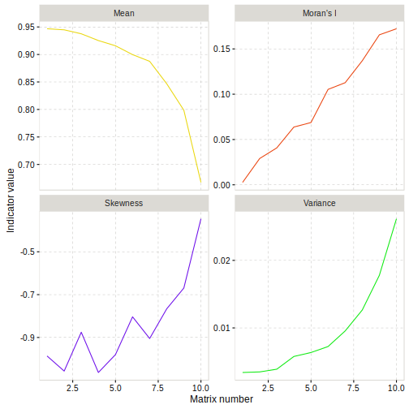

```r
plot(forest.genic)
```

Or assess significance before plotting. This is done by shuffling the original matrix and recomputing the indicators many times. We store the results of the significance assessement into another variable.

```r
forest.gentest <- indictest(forest.genic)
```

And we call the summary function to see what is significant

```r
summary(forest.gentest)
```

```
## Generic Spatial Early-Warnings
##
##  Mat. #  Mean Moran's I P>null     Skewness P>null     Variance P>null
##       1 0.947   0.00265  0.353       -0.987  0.517      0.00340  0.066 .
##       2 0.945   0.02904  0.000 ***   -1.057  0.812      0.00348  0.097 .
##       3 0.938   0.04076  0.000 ***   -0.876  0.425      0.00389  0.119
##       4 0.925   0.06376  0.000 ***   -1.064  0.986      0.00577  0.000 ***
##       5 0.916   0.06873  0.000 ***   -0.980  0.985      0.00636  0.000 ***
##       6 0.900   0.10533  0.000 ***   -0.804  0.916      0.00725  0.000 ***
##       7 0.887   0.11271  0.000 ***   -0.905  0.997      0.00955  0.000 ***
##       8 0.847   0.13693  0.000 ***   -0.766  0.993      0.01265  0.000 ***
##       9 0.799   0.16556  0.000 ***   -0.669  0.998      0.01779  0.000 ***
##      10 0.667   0.17228  0.000 ***   -0.346  0.951      0.02616  0.000 ***
##
##  Significance tested against 999 randomly shuffled matrices
##  Signif. codes:  0 '***' 0.001 '**' 0.01 '*' 0.05 '.' 0.1 ' ' 1
```

What does the trend look like ? Now a grey ribbon is added: it shows the 5% and 95% percentiles of the null distribution.

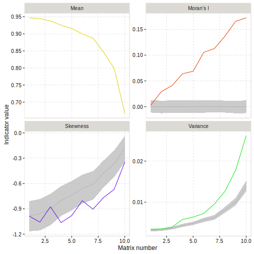

```r
plot(forest.gentest)
```

OK, that looks pretty good ! Of course, options are offered to tweak things a bit. A unique help page gathers all the information needed for the Generic EWS workflow: see `?generic_spews`

```r
forest.genic <- generic_spews(forestdat[['matrices']],
                              subsize = 3,
                              detrend = FALSE,
                              abs_skewness = TRUE,
                              moranI_coarse_grain = TRUE)
```

We can also specify the number of replicates to use in the null distribution

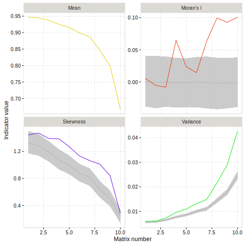

```r
forest.gentest <- indictest(forest.genic, null_replicates = 1999)
plot(forest.gentest) # Compare with figure above
```

Of course, at anytime during this process, we can export the values to a `data.frame` so we can reuse them in other contexts.

```r
head( as.data.frame(forest.gentest) )
```

```
##   replicate indicator       value    null_mean      null_sd     null_95
## 1         1  variance 0.006034694 5.596128e-03 0.0002296471 0.005987918
## 2         1  skewness 1.442555255 1.321189e+00 0.1015632292 1.500375797
## 3         1     moran 0.005441997 4.523853e-05 0.0243152178 0.040769852
## 4         1      mean 0.946800000 9.468000e-01 0.0000000000 0.946800000
## 5         2  variance 0.006016793 5.793482e-03 0.0002345100 0.006198249
## 6         2  skewness 1.472466434 1.288471e+00 0.0982870014 1.457283742
##        null_05       z_score    pval
## 1  0.005237273 -24.362348321 0.03275
## 2  1.168723279 -11.565983070 0.12150
## 3 -0.038438122   0.003581494 0.40550
## 4  0.946800000          -Inf 0.49975
## 5  0.005423462 -24.698606818 0.16650
## 6  1.137495976 -11.636810147 0.04100
```

Individual indicator functions are also available. They can also work on lists of matrices. Note that these functions are here so indicators can be computed more easily as part of another workflow: no plot/summary/print/etc. methods are provided.

```r
forest.varic <- indicator_variance(forestdat[['matrices']])
# See also indicator_skewness, indicator_moran, etc.
```

# Spectral EWS

We will be using the same forestdat dataset to illustrate the spectral EWS workflow. It works just the same:

```r
forest.specic <- spectral_spews(forestdat[["matrices"]])
```

```
## Warning in spectral_spews(forestdat[["matrices"]]): Choosing the 20% lowest
## frequencies for spectral density ratio as none was specified. Use parameter
## sdr_low_range to choose a different value.
```

```
## Warning in spectral_spews(forestdat[["matrices"]]): Choosing the 20%
## highest frequencies for spectral density ratio as none was specified. Use
## parameter sdr_high_range to choose a different value.
```

Mind the warnings here telling us that we are using default values for SDR. Let's see a quick summary of the results.

```r
summary(forest.specic)
```

```
## Spectral Spatial Early-Warnings results
##
##  10 matrices (size: 100x100)
##
##  Replicate # SDR Value
##            1  1.077905
##            2  1.117572
##            3  1.148043
##            4  1.667638
##            5  1.463220
##            6  1.468236
##            7  2.138755
##            8  2.417049
##            9  2.979028
##           10  3.004268
##
## Use as.data.frame() to retrieve r-spectrum and SDR values in a convenient form
```

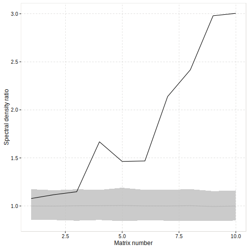

```r
forest.spectest <- indictest(forest.specic)
plot(forest.spectest)
```

```r
# Note that the indictest method here is quite slow as computing the
# rspectrum is expensive (replace with math. approx ?)
```

Now, as you can see the `plot()` method displays the SDR trend, that summarizes the rspectrum values into one summary variable. If one want to have the full spectrum information, it can be displayed using `plot_spectrum`.

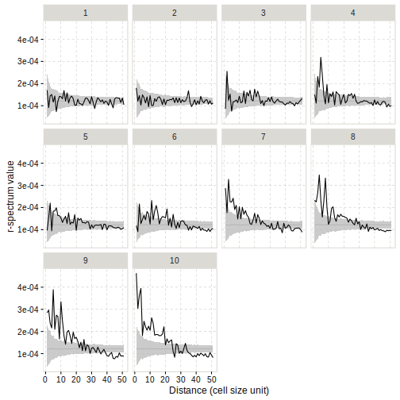

```r
plot_spectrum(forest.spectest)
```

Some options are available to alter how the indicator values are computed

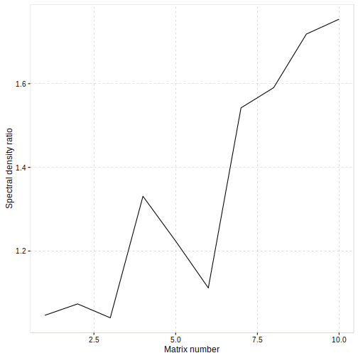

```r
forest.specic <- spectral_spews(forestdat[["matrices"]],
                                sdr_low_range =  c(0, .2),
                                sdr_high_range = c(0, 1))
plot(forest.specic)
```

# PSD-based spatial indicators

We will use forestdat2 for the first part of this example. Let's compute these indicators.

```r
data(forestdat2)
forest.psdic <- patchdistr_spews(forestdat2[['matrices']])
```

See a summary of what has been fitted

```r
summary(forest.psdic)
```

```
## Patch-based Early-Warnings results
##
##  Mat. #   N(uniq.)      Cover Percl.Full Percl.Empt Type  PLR
##       1       1(1) 1.00000000       TRUE      FALSE
##       2       1(1) 0.99116250       TRUE      FALSE
##       3       1(1) 0.97208125       TRUE      FALSE
##       4       3(2) 0.95446875       TRUE      FALSE
##       5       4(3) 0.93431875       TRUE      FALSE
##       6      10(2) 0.91753125       TRUE      FALSE
##       7      25(2) 0.89758125       TRUE      FALSE
##       8      29(5) 0.87991875       TRUE      FALSE   pl
##       9      53(3) 0.86165625       TRUE      FALSE
##      10      87(5) 0.84335000       TRUE      FALSE   pl
##      11     127(8) 0.82362500       TRUE      FALSE   pl 100%
##      12     193(7) 0.80500625       TRUE      FALSE   pl 100%
```

[output cut: 50 more lines]

And plot the indicator values. This is quite a complex figure that summarises percolation status + psd type + powerlaw range. It is still a bit rough so sorry for this.

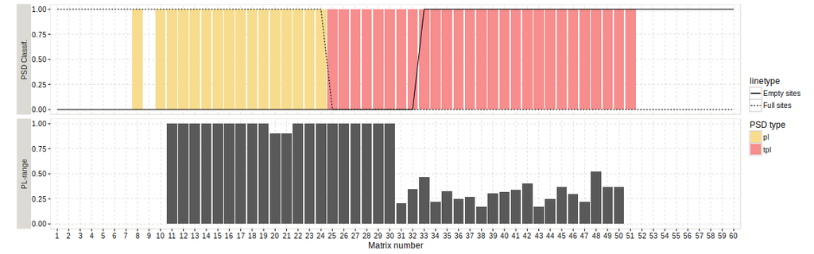

```r
plot(forest.psdic) # try with the along parameter
```

We can also plot the distributions to have a better view of what is going on.

[output not shown]

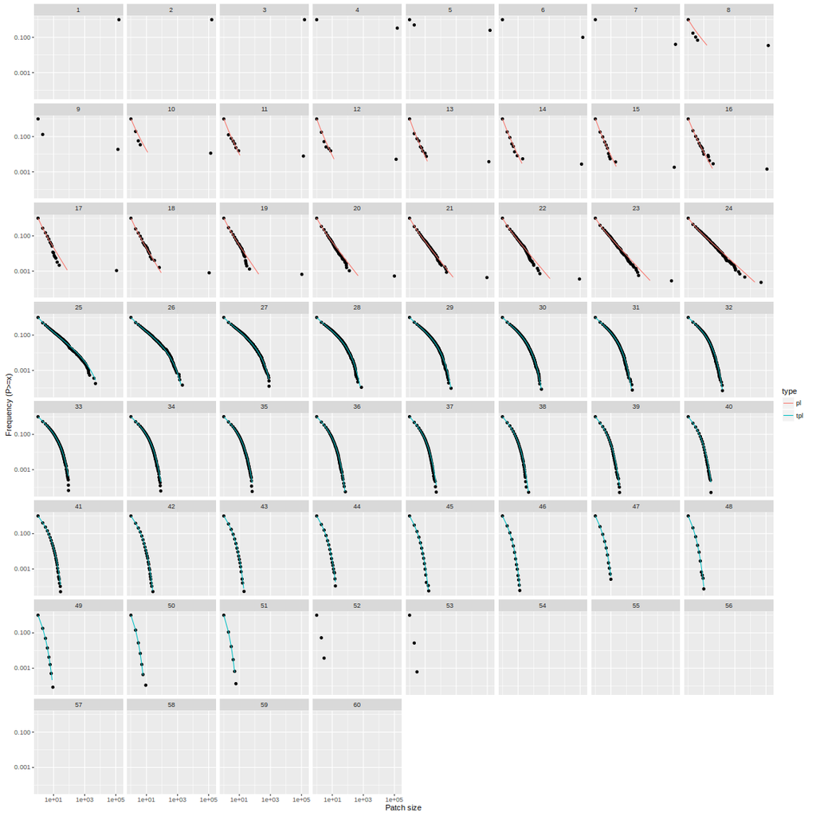

```r
plot_distr(forest.psdic)
```

Next example, this time using aerial images of bushes (from Spain). The dataset is called arid (see Introduction). The first step to compute psd-based spatial indicators is to convert the dataset to binary values. This is enforced in this workflow by checking that all input matrices are of logical type (TRUE/FALSE).

The thresholding itself is a complicated matter and is left to the user: we do not provide any specific function. So let's write our own.

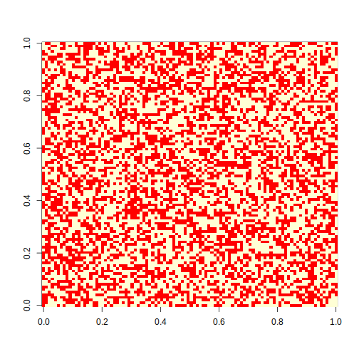

```r
classify_one_matrix <- function(mat) {
  # We consider vegetation to occur when:
  mat > quantile(mat, .45)
}

# Now we have a thresholded dataset
arid.bw <- lapply(arid, classify_one_matrix)
image(arid.bw[[1]])
```

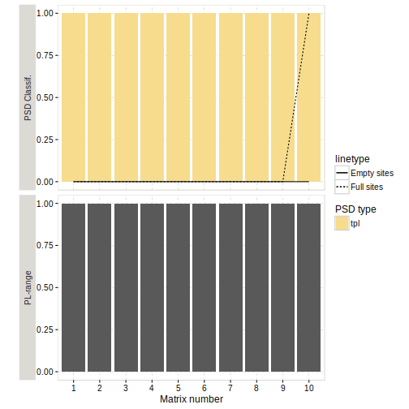

```r
arid.psdic <- patchdistr_spews(arid.bw)

plot(arid.psdic)
```

Of course, individual indicators are also available indvidually, through their own functions

```r
# Not run:
# indicator_psdtype(arid.bw)
# indicator_plrange(forestdat2$matrices)
```

That's it ! For most of these functions, documentation is available through `?` ! It is sometimes missing though (help is gladly accepted ;) ). This document should come with an editable R file example.R, do not hesitate to go back to that file and edit things around.